# Breast Cancer Prediction Project

HarvardX Data Science

Dwaipayan Chatterjee

17 January, 2022

# Overview

This project is related to the Choose-your-own project of the HervardX: PH125.9x Data Science: Capstone course. The present report starts with a general idea of the project and by representing its objectifs.

Then the given dataset will be prepared and setup. An exploratory data analysis is carried out in order to develop a machine learning algorithm that could predict whether a breast cancer cell is benign or malignant until a final model. Results will be explained. Finally, the report will end with some concluding remarks.

## Introduction

A neoplasm is an abnormal mass of tissue, the growth of which exceeds and is uncoordinated with that of the normal tissues, and persists in the same excessive manner after cessation of the stimulus which evoked the change. Cancer can start almost anywhere in the human body, which is made up of 37.200 billion cells. As these tumors grow, some cancer cells can break off and travel to distant places in the body through the blood or the lymph system and form new tumors far from the original one. Unlike malignant tumors, benign tumors do not spread into, or invade, nearby tissues. Breast cancer refers to a pathology in which a tumor develops in the breast tissue. Breast cancer is amongst the most common type of cancer in both sexes since 1975 and causes around 411,000 annual deaths worldwide. It is predicted that the incidence for worldwide cancer will continue to increase, with 23,6 million new cancer cases each year by 2030, corresponding to 68% more cases in comparison to 2012.

Mammography is the most common mass screening tool for an early detection of breast cancers because of its sensitivity in recognising breast masses. After detection of suspicious breast masses, a biopsy test procedure would be carried out, such as Fine Needle Aspirates (FNA), that is the method this report focus on. This method has been showed to be safe, cost-effective, accurate and fast. A small drop of viscous fluid is aspired from the breast masses to be analysed under the microscope. Then, a small region of the breast mass cells is photographed in a grey scale image and further analysed using an image analysis program ‘Xcyt’. This program uses a curve-fitting to determine the edges of the nuclei from initial dots manually placed near these edges by a mouse.

This project will make a performance comparison between different machine learning algorithms in order to to assess the correctness in classifying data with respect to efficiency and effectiveness of each algorithm in terms of accuracy, precision, sensitivity and specificity, in order to find the best diagnosis.

Diagnosis in an early stage is essential to the facilitate the subsequent clinical management of patients and increase the survival rate of breast cancer patients.

The major models used and tested will be supervised learning models (algorithms that learn from labelled data), which are most used in these kinds of data analysis.

The utilization of data science and machine learning approaches in medical fields proves to be prolific as such approaches may be considered of great assistance in the decision making process of medical practitioners. With an unfortunate increasing trend of breast cancer cases, comes also a big deal of data which is of significant use in furthering clinical and medical research, and much more to the application of data science and machine learning in the aforementioned domain.

## Aim of the project

The objective of this report is to train machine learning models to predict whether a breast cancer cell is Benign or Malignant. Data will be transformed and its dimension reduced to reveal patterns in the dataset and create a more robust analysis. As previously said, the optimal model will be selected following the resulting accuracy, sensitivity, and f1 score, amongst other factors. We will later define these metrics. We can use machine learning method to extract the features of cancer cell nuclei image and classify them. It would be helpful to determine whether a given sample appears to be Benign (“B”) or Malignant (“M”).

The machine learning models that we will applicate in this report try to create a classifier that provides a high accuracy level combined with a low rate of false-negatives (high sensitivity).

## Dataset

The present report covers the Breast Cancer Wisconsin (Diagnostic) DataSet (https://www.kaggle.com/uciml/breast-cancer-wisconsin-data/version/2) created by Dr. William H. Wolberg, physician at the University Of Wisconsin Hospital at Madison, Wisconsin, USA. The data used for this project was collected in 1993 by the University of Wisconsin and it is composed by the biopsy result of 569 patients in Wisconsin Hospital.

• [Wisconsin Breast Cancer Diagnostic Dataset] https://www.kaggle.com/uciml/breast-cancer-wisconsin-data/version/2

The .csv format file containing the data is loaded from my personal github account.

The dataset’s features describe characteristics of the cell nuclei on the image. The features information are specified below:

- Attribute Information:
  1. ID number
  2. Diagnosis (M = malignant, B = benign)
- Ten features were computed for each cell nucleus:
1. radius: mean of distances from center to points on the perimeter
2. texture: standard deviation of grey-scale values
3. perimeter
4. area: Number of pixels inside contour + ½ for pixels on perimeter
5. smoothness: local variation in radius lengths), , t
6. compactness: perimeter^2 / area – 1.0 ; this dimensionless number is at a minimum with a circular disk and increases with the irregularity of the boundary, but this measure also increases for elongated cell nuclei, which is not indicative of malignancy
7. concavity: severity of concave portions of the contour
8. concave points: number of concave portions of the contour
9. symmetry
10. fractal dimension: “coastline approximation” - 1; a higher value corresponds a less regular contour and thus to a higher probability of malignancy

The mean, standard error and “worst” or largest (mean of the three largest values) of these features were computed for each image, resulting in 30 variables. From this diagnosis, 357 of the cases were classified as benign tumors and 212 were considered malignant tumors. All cancers and some of the benign masses were histologically confirmed

The column 33 is invalid.

```r
data$diagnosis <- as.factor(data$diagnosis)
# the 33 column is invalid
data[,33] <- NULL
```

# Methods and Analysis

## Data Analysis

By observing our dataset, we found that it contains 569 observations with 32 variables.

```r
str(data)
```

```
'data.frame':   569 obs. of  32 variables:
 $ id                     : int  842302 842517 84300903 84348301 84358402 843786 844359 84458202 844981 84501001 ...
 $ diagnosis              : Factor w/ 2 levels "B","M": 2 2 2 2 2 2 2 2 2 2 ...
 $ radius_mean            : num  18 20.6 19.7 11.4 20.3 ...
 $ texture_mean           : num  10.4 17.8 21.2 20.4 14.3 ...
 $ perimeter_mean         : num  122.8 132.9 130 77.6 135.1 ...
 $ area_mean              : num  1001 1326 1203 386 1297 ...
 $ smoothness_mean        : num  0.1184 0.0847 0.1096 0.1425 0.1003 ...
 $ compactness_mean       : num  0.2776 0.0786 0.1599 0.2839 0.1328 ...
 $ concavity_mean         : num  0.3001 0.0869 0.1974 0.2414 0.198 ...
 $ concave.points_mean    : num  0.1471 0.0702 0.1279 0.1052 0.1043 ...
 $ symmetry_mean          : num  0.242 0.181 0.207 0.26 0.181 ...
 $ fractal_dimension_mean : num  0.0787 0.0567 0.06 0.0974 0.0588 ...
 $ radius_se              : num  1.095 0.543 0.746 0.496 0.757 ...
 $ texture_se             : num  0.905 0.734 0.787 1.156 0.781 ...
```

[output cut: 18 more lines]

```r
head(data)
```

```
        id diagnosis radius_mean texture_mean perimeter_mean area_mean
1   842302         M       17.99        10.38         122.80    1001.0
2   842517         M       20.57        17.77         132.90    1326.0
3 84300903         M       19.69        21.25         130.00    1203.0
4 84348301         M       11.42        20.38          77.58     386.1
5 84358402         M       20.29        14.34         135.10    1297.0
6   843786         M       12.45        15.70          82.57     477.1
  smoothness_mean compactness_mean concavity_mean concave.points_mean
1         0.11840          0.27760         0.3001             0.14710
2         0.08474          0.07864         0.0869             0.07017
3         0.10960          0.15990         0.1974             0.12790
4         0.14250          0.28390         0.2414             0.10520
5         0.10030          0.13280         0.1980             0.10430
6         0.12780          0.17000         0.1578             0.08089
  symmetry_mean fractal_dimension_mean radius_se texture_se perimeter_se
```

[output cut: 34 more lines]

```r
summary(data)
```

```
       id            diagnosis  radius_mean      texture_mean
 Min.   :     8670   B:357     Min.   : 6.981   Min.   : 9.71
 1st Qu.:   869218   M:212     1st Qu.:11.700   1st Qu.:16.17
 Median :   906024             Median :13.370   Median :18.84
 Mean   : 30371831             Mean   :14.127   Mean   :19.29
 3rd Qu.:  8813129             3rd Qu.:15.780   3rd Qu.:21.80
 Max.   :911320502             Max.   :28.110   Max.   :39.28
 perimeter_mean     area_mean      smoothness_mean   compactness_mean
 Min.   : 43.79   Min.   : 143.5   Min.   :0.05263   Min.   :0.01938
 1st Qu.: 75.17   1st Qu.: 420.3   1st Qu.:0.08637   1st Qu.:0.06492
 Median : 86.24   Median : 551.1   Median :0.09587   Median :0.09263
 Mean   : 91.97   Mean   : 654.9   Mean   :0.09636   Mean   :0.10434
 3rd Qu.:104.10   3rd Qu.: 782.7   3rd Qu.:0.10530   3rd Qu.:0.13040
 Max.   :188.50   Max.   :2501.0   Max.   :0.16340   Max.   :0.34540
 concavity_mean    concave.points_mean symmetry_mean    fractal_dimension_mean
 Min.   :0.00000   Min.   :0.00000     Min.   :0.1060   Min.   :0.04996
 1st Qu.:0.02956   1st Qu.:0.02031     1st Qu.:0.1619   1st Qu.:0.05770
 Median :0.06154   Median :0.03350     Median :0.1792   Median :0.06154
 Mean   :0.08880   Mean   :0.04892     Mean   :0.1812   Mean   :0.06280
 3rd Qu.:0.13070   3rd Qu.:0.07400     3rd Qu.:0.1957   3rd Qu.:0.06612
 Max.   :0.42680   Max.   :0.20120     Max.   :0.3040   Max.   :0.09744
   radius_se        texture_se      perimeter_se       area_se
 Min.   :0.1115   Min.   :0.3602   Min.   : 0.757   Min.   :  6.802
 1st Qu.:0.2324   1st Qu.:0.8339   1st Qu.: 1.606   1st Qu.: 17.850
 Median :0.3242   Median :1.1080   Median : 2.287   Median : 24.530
 Mean   :0.4052   Mean   :1.2169   Mean   : 2.866   Mean   : 40.337
 3rd Qu.:0.4789   3rd Qu.:1.4740   3rd Qu.: 3.357   3rd Qu.: 45.190
 Max.   :2.8730   Max.   :4.8850   Max.   :21.980   Max.   :542.200
 smoothness_se      compactness_se      concavity_se     concave.points_se
 Min.   :0.001713   Min.   :0.002252   Min.   :0.00000   Min.   :0.000000
 1st Qu.:0.005169   1st Qu.:0.013080   1st Qu.:0.01509   1st Qu.:0.007638
 Median :0.006380   Median :0.020450   Median :0.02589   Median :0.010930
 Mean   :0.007041   Mean   :0.025478   Mean   :0.03189   Mean   :0.011796
 3rd Qu.:0.008146   3rd Qu.:0.032450   3rd Qu.:0.04205   3rd Qu.:0.014710
 Max.   :0.031130   Max.   :0.135400   Max.   :0.39600   Max.   :0.052790
  symmetry_se       fractal_dimension_se  radius_worst   texture_worst
 Min.   :0.007882   Min.   :0.0008948    Min.   : 7.93   Min.   :12.02
 1st Qu.:0.015160   1st Qu.:0.0022480    1st Qu.:13.01   1st Qu.:21.08
 Median :0.018730   Median :0.0031870    Median :14.97   Median :25.41
 Mean   :0.020542   Mean   :0.0037949    Mean   :16.27   Mean   :25.68
 3rd Qu.:0.023480   3rd Qu.:0.0045580    3rd Qu.:18.79   3rd Qu.:29.72
 Max.   :0.078950   Max.   :0.0298400    Max.   :36.04   Max.   :49.54
 perimeter_worst    area_worst     smoothness_worst  compactness_worst
 Min.   : 50.41   Min.   : 185.2   Min.   :0.07117   Min.   :0.02729
 1st Qu.: 84.11   1st Qu.: 515.3   1st Qu.:0.11660   1st Qu.:0.14720
 Median : 97.66   Median : 686.5   Median :0.13130   Median :0.21190
 Mean   :107.26   Mean   : 880.6   Mean   :0.13237   Mean   :0.25427
 3rd Qu.:125.40   3rd Qu.:1084.0   3rd Qu.:0.14600   3rd Qu.:0.33910
 Max.   :251.20   Max.   :4254.0   Max.   :0.22260   Max.   :1.05800
 concavity_worst  concave.points_worst symmetry_worst   fractal_dimension_worst
 Min.   :0.0000   Min.   :0.00000      Min.   :0.1565   Min.   :0.05504
 1st Qu.:0.1145   1st Qu.:0.06493      1st Qu.:0.2504   1st Qu.:0.07146
 Median :0.2267   Median :0.09993      Median :0.2822   Median :0.08004
 Mean   :0.2722   Mean   :0.11461      Mean   :0.2901   Mean   :0.08395
 3rd Qu.:0.3829   3rd Qu.:0.16140      3rd Qu.:0.3179   3rd Qu.:0.09208
 Max.   :1.2520   Max.   :0.29100      Max.   :0.6638   Max.   :0.20750
```

We have to check if the dataset has any missing value:

```
$id
[1] 0

$diagnosis
[1] 0

$radius_mean
[1] 0

$texture_mean
[1] 0

$perimeter_mean
[1] 0

$area_mean
[1] 0

$smoothness_mean
[1] 0

$compactness_mean
[1] 0

$concavity_mean
[1] 0

$concave.points_mean
[1] 0

$symmetry_mean
[1] 0

$fractal_dimension_mean
[1] 0

$radius_se
[1] 0

$texture_se
```

[output cut: 40 more lines]

```

$compactness_worst
[1] 0

$concavity_worst
[1] 0

$concave.points_worst
[1] 0

$symmetry_worst
[1] 0

$fractal_dimension_worst
[1] 0
```

It results that there aren’t NA values. By analysing the the dataset we discover that it is a bit unbalanced in its proportions:

```r
prop.table(table(data$diagnosis))
```

```
        B         M
0.6274165 0.3725835
```

Also the plot of proportions confirms that the target variable is slightly unbalanced.

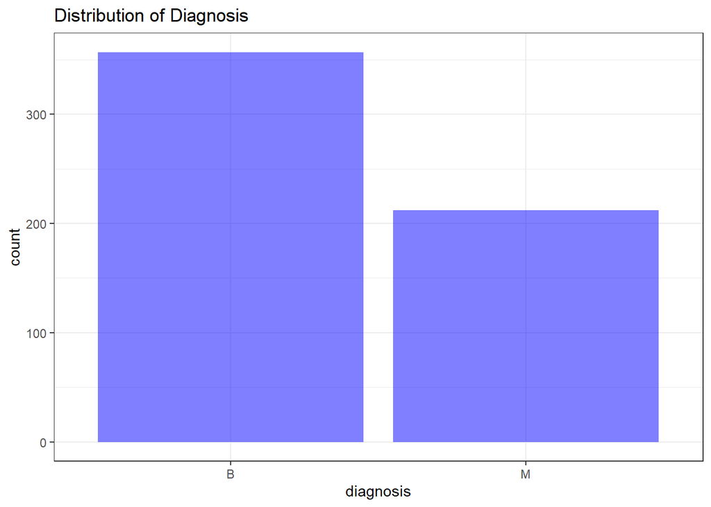

```r
options(repr.plot.width=4, repr.plot.height=4)
ggplot(data, aes(x=diagnosis))+geom_bar(fill="blue",alpha=0.5)+theme_bw()+labs(title="Distribution of Diagnosis")
```

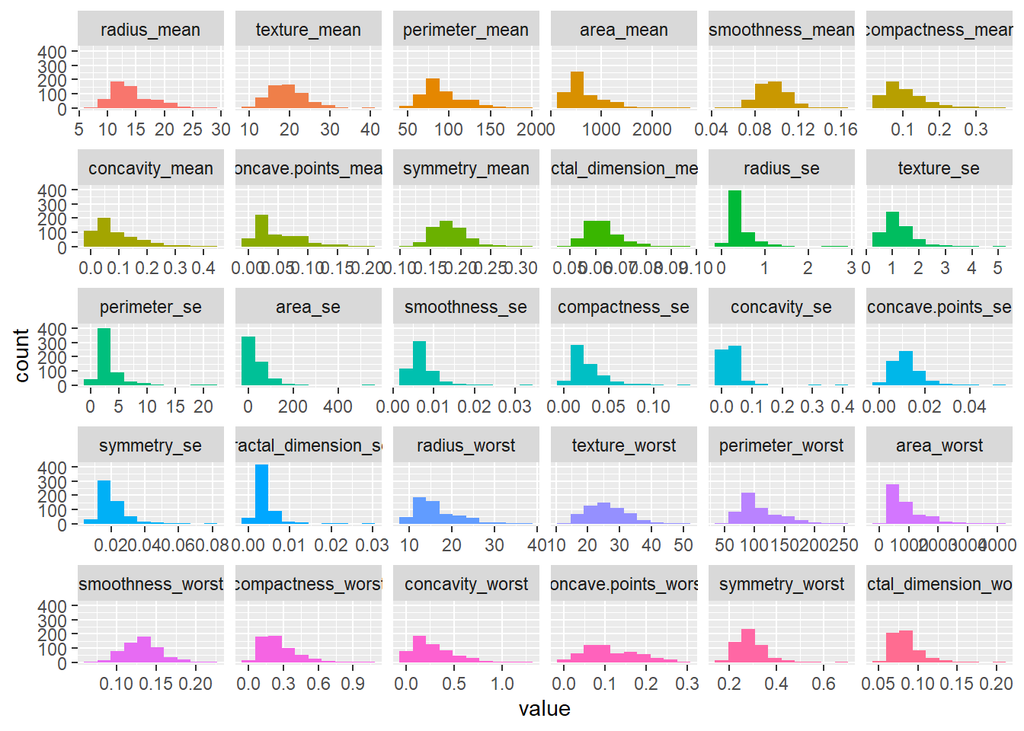

```r
plot_num(data %>% select(-id), bins=10)
```

Now we have to check if the is any correlation between variables as machine learning algorithms assume that the predictor variables are independent from each others.

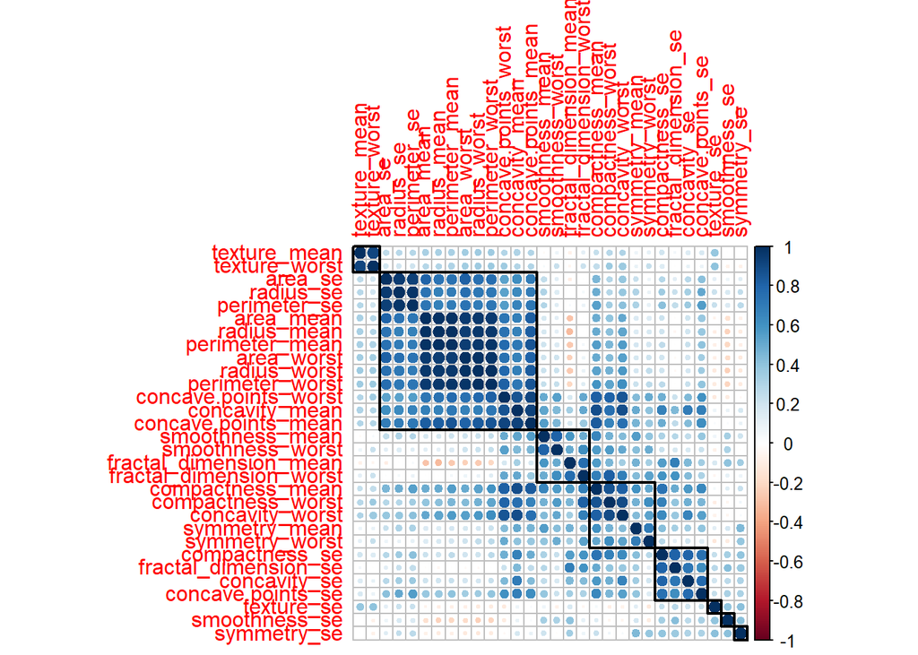

```r
correlationMatrix <- cor(data[,3:ncol(data)])
corrplot(correlationMatrix, order = "hclust", tl.cex = 1, addrect = 8)
```

As shown by this plot, many variables are highly correlated with each others. Many methods perform better if highly correlated attributes are removed. The Caret R package provides the findCorrelation which will analyze a correlation matrix of your data’s attributes report on attributes that can be removed. Because of much correlation some machine learning models could fail.

```r
# find attributes that are highly corrected (ideally >0.90)
highlyCorrelated <- findCorrelation(correlationMatrix, cutoff=0.9)
# print indexes of highly correlated attributes
print(highlyCorrelated)
```

```
 [1]  7  8 23 21  3 24  1 13 14  2
```

Selecting the right features in our data can mean the difference between mediocre performance with long training times and great performance with short training times.

```r
# Remove correlated variables
data2 <- data %>%select(-highlyCorrelated)
# number of columns after removing correlated variables
ncol(data2)
```

```
[1] 22
```

The new dataset has loss 10 variables.

## Modelling Approach

### Modelling

Principal Component Analysis (PCA).

To avoid redundancy and relevancy, we used the function ‘prncomp’ to calculate the Principal Component Analysis (PCA) and select the rights components to avoid correlated variables that can be detrimental to our clustering analysis. One of the common problems in analysis of complex data comes from a large number of variables, which requires a large amount of memory and computation power. This is where PCA comes in. It is a technique to reduce the dimension of the feature space by feature extraction. The main idea of PCA is to reduce the dimensionality of a data set consisting of many variables correlated with each other, either heavily or lightly, while retaining the variation present in the dataset, up to the maximum extent. The same is done by transforming the variables to a new set of variables, which are known as the principal components (or simply, the PCs) and are orthogonal, ordered such that the retention of variation present in the original variables decrease as we move down in the order.

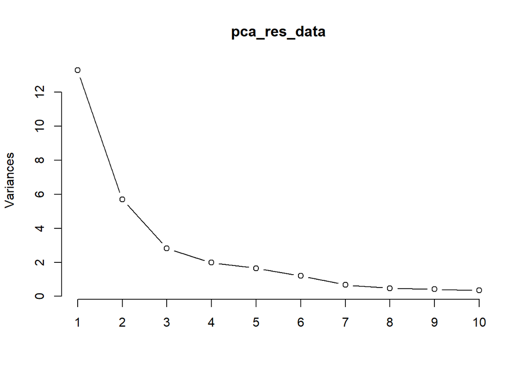

```r
pca_res_data <- prcomp(data[,3:ncol(data)], center = TRUE, scale = TRUE)
plot(pca_res_data, type="l")
```

```r
summary(pca_res_data)
```

```
Importance of components:
                          PC1    PC2     PC3     PC4     PC5     PC6     PC7
Standard deviation     3.6444 2.3857 1.67867 1.40735 1.28403 1.09880 0.82172
Proportion of Variance 0.4427 0.1897 0.09393 0.06602 0.05496 0.04025 0.02251
Cumulative Proportion  0.4427 0.6324 0.72636 0.79239 0.84734 0.88759 0.91010
                           PC8    PC9    PC10   PC11    PC12    PC13    PC14
Standard deviation     0.69037 0.6457 0.59219 0.5421 0.51104 0.49128 0.39624
Proportion of Variance 0.01589 0.0139 0.01169 0.0098 0.00871 0.00805 0.00523
Cumulative Proportion  0.92598 0.9399 0.95157 0.9614 0.97007 0.97812 0.98335
                          PC15    PC16    PC17    PC18    PC19    PC20   PC21
Standard deviation     0.30681 0.28260 0.24372 0.22939 0.22244 0.17652 0.1731
Proportion of Variance 0.00314 0.00266 0.00198 0.00175 0.00165 0.00104 0.0010
Cumulative Proportion  0.98649 0.98915 0.99113 0.99288 0.99453 0.99557 0.9966
                          PC22    PC23   PC24    PC25    PC26    PC27    PC28
Standard deviation     0.16565 0.15602 0.1344 0.12442 0.09043 0.08307 0.03987
Proportion of Variance 0.00091 0.00081 0.0006 0.00052 0.00027 0.00023 0.00005
Cumulative Proportion  0.99749 0.99830 0.9989 0.99942 0.99969 0.99992 0.99997
                          PC29    PC30
Standard deviation     0.02736 0.01153
Proportion of Variance 0.00002 0.00000
Cumulative Proportion  1.00000 1.00000
```

As we can observe from the above table, the two first components explains the 0.6324 of the variance. We need 10 principal components to explain more than 0.95 of the variance and 17 to explain more than 0.99.

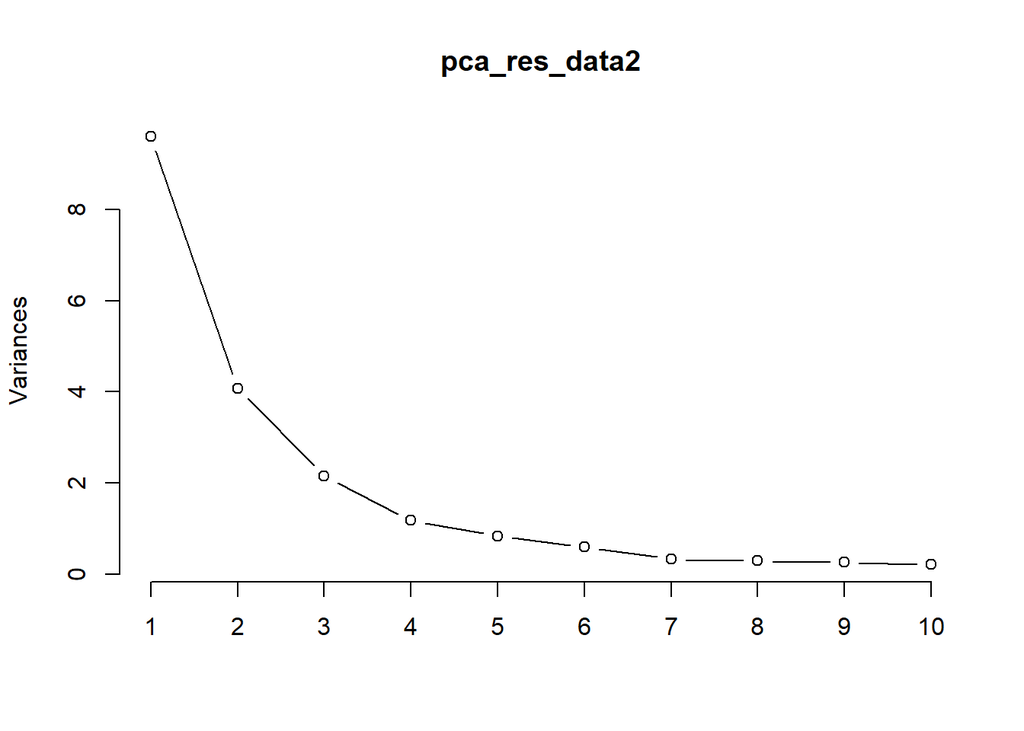

```r
pca_res_data2 <- prcomp(data2[,3:ncol(data2)], center = TRUE, scale = TRUE)
plot(pca_res_data2, type="l")
```

```r
summary(pca_res_data2)
```

```
Importance of components:
                          PC1    PC2    PC3    PC4     PC5     PC6     PC7
Standard deviation     3.0980 2.0196 1.4663 1.0845 0.91561 0.77019 0.57227
Proportion of Variance 0.4799 0.2039 0.1075 0.0588 0.04192 0.02966 0.01637
Cumulative Proportion  0.4799 0.6838 0.7913 0.8501 0.89205 0.92171 0.93808
                           PC8     PC9    PC10    PC11    PC12    PC13    PC14
Standard deviation     0.53641 0.50898 0.45726 0.36641 0.31778 0.28802 0.21369
Proportion of Variance 0.01439 0.01295 0.01045 0.00671 0.00505 0.00415 0.00228
Cumulative Proportion  0.95247 0.96542 0.97588 0.98259 0.98764 0.99179 0.99407
                         PC15    PC16    PC17    PC18    PC19    PC20
Standard deviation     0.1846 0.15579 0.15393 0.14782 0.09636 0.07375
Proportion of Variance 0.0017 0.00121 0.00118 0.00109 0.00046 0.00027
Cumulative Proportion  0.9958 0.99699 0.99817 0.99926 0.99973 1.00000
```

The above table shows that 95% of the variance is explained with 8 PC’s in the transformed dataset data2.

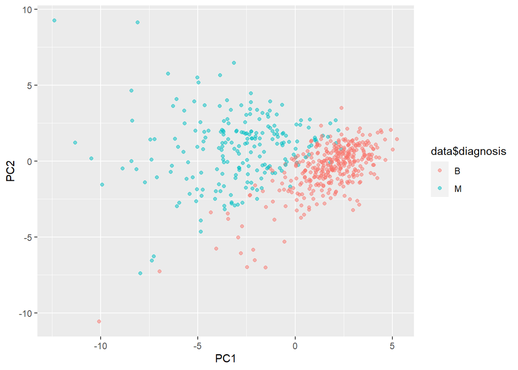

```r
pca_df <- as.data.frame(pca_res_data2$x)
ggplot(pca_df, aes(x=PC1, y=PC2, col=data$diagnosis)) + geom_point(alpha=0.5)
```

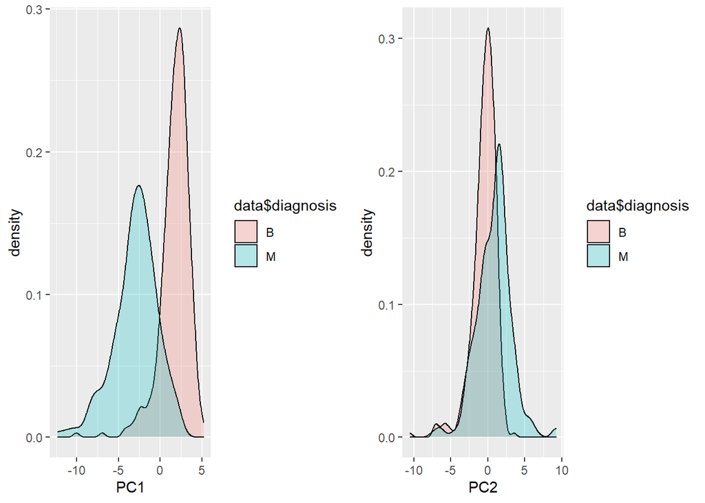

```r
g_pc1 <- ggplot(pca_df, aes(x=PC1, fill=data$diagnosis)) + geom_density(alpha=0.25)
g_pc2 <- ggplot(pca_df, aes(x=PC2, fill=data$diagnosis)) + geom_density(alpha=0.25)
grid.arrange(g_pc1, g_pc2, ncol=2)
```

Linear Discriminant Analysis (LDA)

Another approach is to use the Linear Discriminant Analysis (LDA) instead of PCA. LDA takes in consideration the different classes and could get better results. The particularity of LDA is that it models the distribution of predictors separately in each of the response classes, and then it uses Bayes’ theorem to estimate the probability. It is important to know that LDA assumes a normal distribution for each class, a class-specific mean, and a common variance.

```r
lda_res_data <- MASS::lda(diagnosis~., data = data, center = TRUE, scale = TRUE)
lda_res_data
```

```
Call:
lda(diagnosis ~ ., data = data, center = TRUE, scale = TRUE)

Prior probabilities of groups:
        B         M
0.6274165 0.3725835

Group means:
        id radius_mean texture_mean perimeter_mean area_mean smoothness_mean
B 26543825    12.14652     17.91476       78.07541  462.7902      0.09247765
M 36818050    17.46283     21.60491      115.36538  978.3764      0.10289849
  compactness_mean concavity_mean concave.points_mean symmetry_mean
B       0.08008462     0.04605762          0.02571741      0.174186
M       0.14518778     0.16077472          0.08799000      0.192909
  fractal_dimension_mean radius_se texture_se perimeter_se  area_se
B             0.06286739 0.2840824   1.220380     2.000321 21.13515
M             0.06268009 0.6090825   1.210915     4.323929 72.67241
  smoothness_se compactness_se concavity_se concave.points_se symmetry_se
B   0.007195902     0.02143825   0.02599674       0.009857653  0.02058381
M   0.006780094     0.03228117   0.04182401       0.015060472  0.02047240
  fractal_dimension_se radius_worst texture_worst perimeter_worst area_worst
B          0.003636051     13.37980      23.51507        87.00594   558.8994
M          0.004062406     21.13481      29.31821       141.37033  1422.2863
  smoothness_worst compactness_worst concavity_worst concave.points_worst
B        0.1249595         0.1826725       0.1662377           0.07444434
M        0.1448452         0.3748241       0.4506056           0.18223731
  symmetry_worst fractal_dimension_worst
B      0.2702459              0.07944207
M      0.3234679              0.09152995

Coefficients of linear discriminants:
                                  LD1
id                      -2.512117e-10
radius_mean             -1.080876e+00
texture_mean             2.338408e-02
perimeter_mean           1.172707e-01
area_mean                1.595690e-03
smoothness_mean          5.251575e-01
compactness_mean        -2.094197e+01
concavity_mean           6.955923e+00
```

[output cut: 8 more lines]

```
compactness_se           1.387026e-01
concavity_se            -1.768261e+01
concave.points_se        5.350520e+01
symmetry_se              8.143611e+00
fractal_dimension_se    -3.431356e+01
radius_worst             9.677207e-01
texture_worst            3.540591e-02
perimeter_worst         -1.204507e-02
area_worst              -5.012127e-03
smoothness_worst         2.612258e+00
compactness_worst        3.636892e-01
concavity_worst          1.880699e+00
concave.points_worst     2.218189e+00
symmetry_worst           2.783102e+00
fractal_dimension_worst  2.117830e+01
```

```r
#Data frame of the LDA for visualization purposes
lda_df_predict <- predict(lda_res_data, data)$x %>% as.data.frame() %>% cbind(diagnosis=data$diagnosis)
```

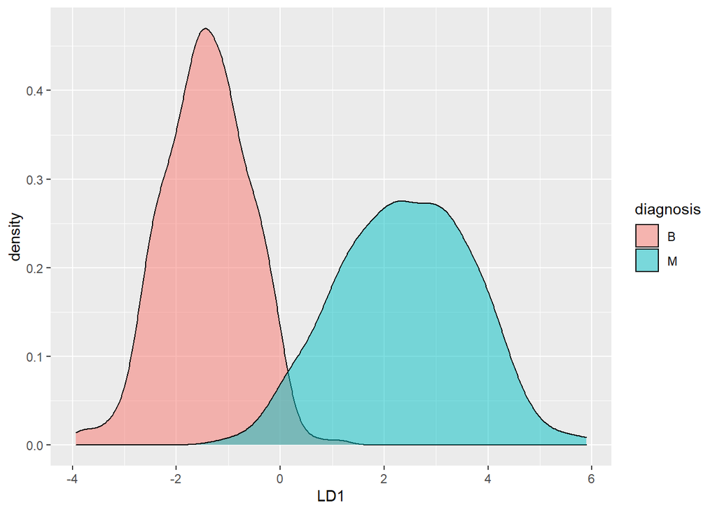

```r
ggplot(lda_df_predict, aes(x=LD1, fill=diagnosis)) + geom_density(alpha=0.5)
```

### Model creation

We are going to get a training and a testing set to use when building some models. We split the modified dataset into Train (80%) and Test (20%), in order to predict is whether a cancer cell is Benign or Malignant, by building machine learning classification models.

```r
set.seed(1815)
data3 <- cbind (diagnosis=data$diagnosis, data2)
data_sampling_index <- createDataPartition(data$diagnosis, times=1, p=0.8, list = FALSE)
train_data <- data3[data_sampling_index, ]
test_data <- data3[-data_sampling_index, ]


fitControl <- trainControl(method="cv",    #Control the computational nuances of thetrainfunction
                           number = 15,    #Either the number of folds or number of resampling iterations
                           classProbs = TRUE,
                           summaryFunction = twoClassSummary)
```

### Naive Bayes Model

The Naive Bayesian classifier is based on Bayes’ theorem with the independence assumptions between predictors. A Naive Bayesian model is easy to build, with no complicated iterative parameter estimation which makes it particularly useful for very large datasets. Bayes theorem provides a way of calculating the posterior probability, P(c|x), from P(c), P(x), and P(x|c). Naive Bayes classifier assume that the effect of the value of a predictor (x) on a given class (c) is independent of the values of other predictors. This assumption is called class conditional independence.

```r
model_naiveb <- train(diagnosis~.,
                      train_data,
                      method="nb",
                      metric="ROC",
                      preProcess=c('center', 'scale'), #in order to normalize the data
                      trace=FALSE,
                      trControl=fitControl)

prediction_naiveb <- predict(model_naiveb, test_data)
confusionmatrix_naiveb <- confusionMatrix(prediction_naiveb, test_data$diagnosis, positive = "M")
confusionmatrix_naiveb
```

```
Confusion Matrix and Statistics

          Reference
Prediction  B  M
         B 66  3
         M  5 39

               Accuracy : 0.9292
                 95% CI : (0.8653, 0.9689)
    No Information Rate : 0.6283
    P-Value [Acc > NIR] : 1.372e-13

                  Kappa : 0.8499

 Mcnemar's Test P-Value : 0.7237

            Sensitivity : 0.9286
            Specificity : 0.9296
         Pos Pred Value : 0.8864
         Neg Pred Value : 0.9565
             Prevalence : 0.3717
         Detection Rate : 0.3451
   Detection Prevalence : 0.3894
      Balanced Accuracy : 0.9291

       'Positive' Class : M
```

We can note the accuracy with such model. We will later describe better these metrics, where: Sensitivity (recall) represent the true positive rate: the proportions of actual positives correctly identified. Specificity is the true negative rate: the proportion of actual negatives correctly identified. Accuracy is the general score of the classifier model performance as it is the ratio of how many samples are correctly classified to all samples. F1 score: the harmonic mean of precision and sensitivity. Accuracy and F1 score would be used to compare the result with the benchmark model. Precision: the number of correct positive results divided by the number of all positive results returned by the classifier.

The most important variables that permit the best prediction and contribute the most to the model are the following:

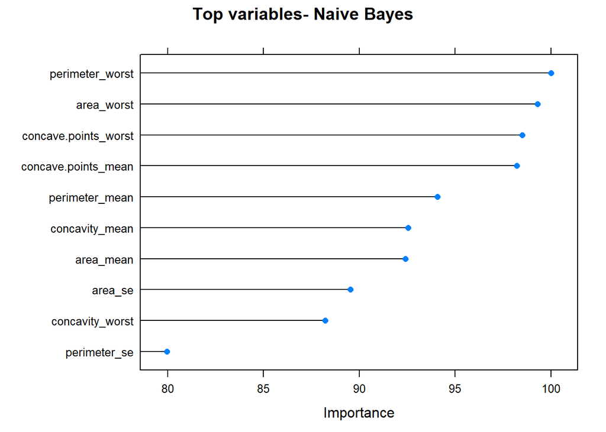

```r
plot(varImp(model_naiveb), top=10, main="Top variables- Naive Bayes")
```

### Logistic Regression Model

Logistic Regression is widly used for binary classification like (0,1). The binary logistic model is used to estimate the probability of a binary response based on one or more predictor (or independent) variables (features).

```r
model_logreg<- train(diagnosis ~., data = train_data, method = "glm",
                     metric = "ROC",

                     preProcess = c("scale", "center"),  # in order to normalize the data
                     trControl= fitControl)
prediction_logreg<- predict(model_logreg, test_data)

# Check results
confusionmatrix_logreg <- confusionMatrix(prediction_logreg, test_data$diagnosis, positive = "M")
confusionmatrix_logreg
```

```
Confusion Matrix and Statistics

          Reference
Prediction  B  M
         B 67  0
         M  4 42

               Accuracy : 0.9646
                 95% CI : (0.9118, 0.9903)
    No Information Rate : 0.6283
    P-Value [Acc > NIR] : <2e-16

                  Kappa : 0.9257

 Mcnemar's Test P-Value : 0.1336

            Sensitivity : 1.0000
            Specificity : 0.9437
         Pos Pred Value : 0.9130
         Neg Pred Value : 1.0000
             Prevalence : 0.3717
         Detection Rate : 0.3717
   Detection Prevalence : 0.4071
      Balanced Accuracy : 0.9718

       'Positive' Class : M
```

The most important variables that permit the best prediction and contribute the most to the model are the following:

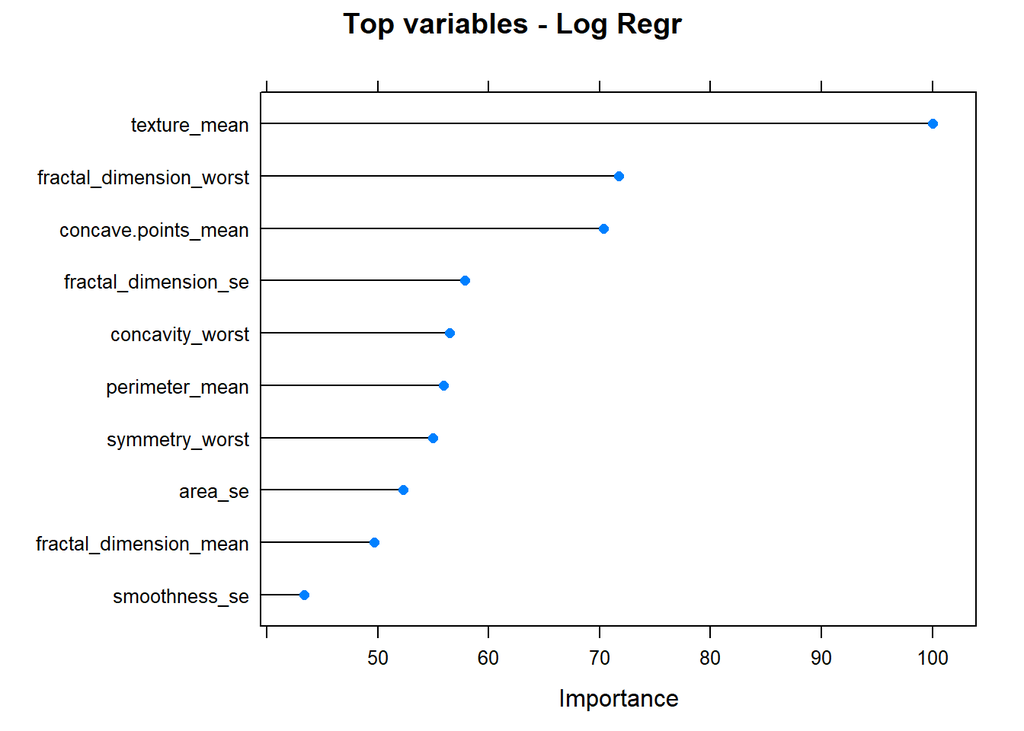

```r
plot(varImp(model_logreg), top=10, main="Top variables - Log Regr")
```

### Random Forest Model

Random forests are a very popular machine learning approach that addresses the shortcomings of decision trees using a clever idea. The goal is to improve prediction performance and reduce instability by averaging multiple decision trees (a forest of trees constructed with randomness). Random forest is another ensemble method based on decision trees. It split data into sub-samples, trains decision tree classifiers on each sub-sample and averages prediction of each classifier. Splitting dataset causes higher bias but it is compensated by large decrease in variance. Random Forest is a supervised learning algorithm and it is flexible, easy to use machine learning algorithm that produces, even without hyper-parameter tuning, a great result most of the time. It is also one of the most used algorithms, because of it’s simplicity and the fact that it can be used for both classification and regression tasks. Random forest builds multiple decision trees and merges them together to get a more accurate and stable prediction.

```r
model_randomforest <- train(diagnosis~.,
                            train_data,
                            method="rf",  #also recommended ranger, because it is a lot faster than original randomForest (rf)
                            metric="ROC",
                            #tuneLength=10,
                            #tuneGrid = expand.grid(mtry = c(2, 3, 6)),
                            preProcess = c('center', 'scale'),
                            trControl=fitControl)

prediction_randomforest <- predict(model_randomforest, test_data)

#Check results
confusionmatrix_randomforest <- confusionMatrix(prediction_randomforest, test_data$diagnosis, positive = "M")
confusionmatrix_randomforest
```

```
Confusion Matrix and Statistics

          Reference
Prediction  B  M
         B 70  1
         M  1 41

               Accuracy : 0.9823
                 95% CI : (0.9375, 0.9978)
    No Information Rate : 0.6283
    P-Value [Acc > NIR] : <2e-16

                  Kappa : 0.9621

 Mcnemar's Test P-Value : 1

            Sensitivity : 0.9762
            Specificity : 0.9859
         Pos Pred Value : 0.9762
         Neg Pred Value : 0.9859
             Prevalence : 0.3717
         Detection Rate : 0.3628
   Detection Prevalence : 0.3717
      Balanced Accuracy : 0.9811

       'Positive' Class : M
```

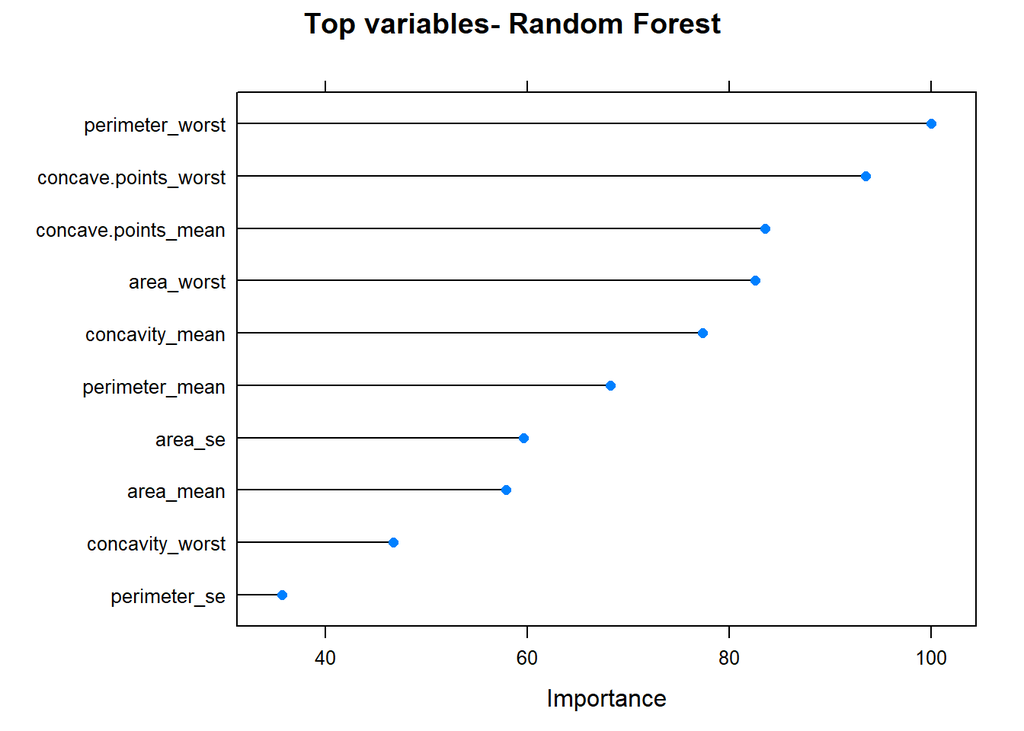

```r
plot(varImp(model_randomforest), top=10, main="Top variables- Random Forest")
```

### K Nearest Neighbor (KNN) Model

KNN (K-Nearest Neighbors) is one of many (supervised learning) algorithms used in data mining and machine learning, it’s a classifier algorithm where the learning is based “how similar” is a data from other. K nearest neighbors is a simple algorithm that stores all available cases and classifies new cases based on a similarity measure (e.g., distance functions).

```r
model_knn <- train(diagnosis~.,
                   train_data,
                   method="knn",
                   metric="ROC",
                   preProcess = c('center', 'scale'),
                   tuneLength=10, #The tuneLength parameter tells the algorithm to try different default values for the main parameter
                   #In this case we used 10 default values
                   trControl=fitControl)

prediction_knn <- predict(model_knn, test_data)
confusionmatrix_knn <- confusionMatrix(prediction_knn, test_data$diagnosis, positive = "M")
confusionmatrix_knn
```

```
Confusion Matrix and Statistics

          Reference
Prediction  B  M
         B 71  3
         M  0 39

               Accuracy : 0.9735
                 95% CI : (0.9244, 0.9945)
    No Information Rate : 0.6283
    P-Value [Acc > NIR] : <2e-16

                  Kappa : 0.9423

 Mcnemar's Test P-Value : 0.2482

            Sensitivity : 0.9286
            Specificity : 1.0000
         Pos Pred Value : 1.0000
         Neg Pred Value : 0.9595
             Prevalence : 0.3717
         Detection Rate : 0.3451
   Detection Prevalence : 0.3451
      Balanced Accuracy : 0.9643

       'Positive' Class : M
```

The most important variables that permit the best prediction and contribute the most to the model are the following:

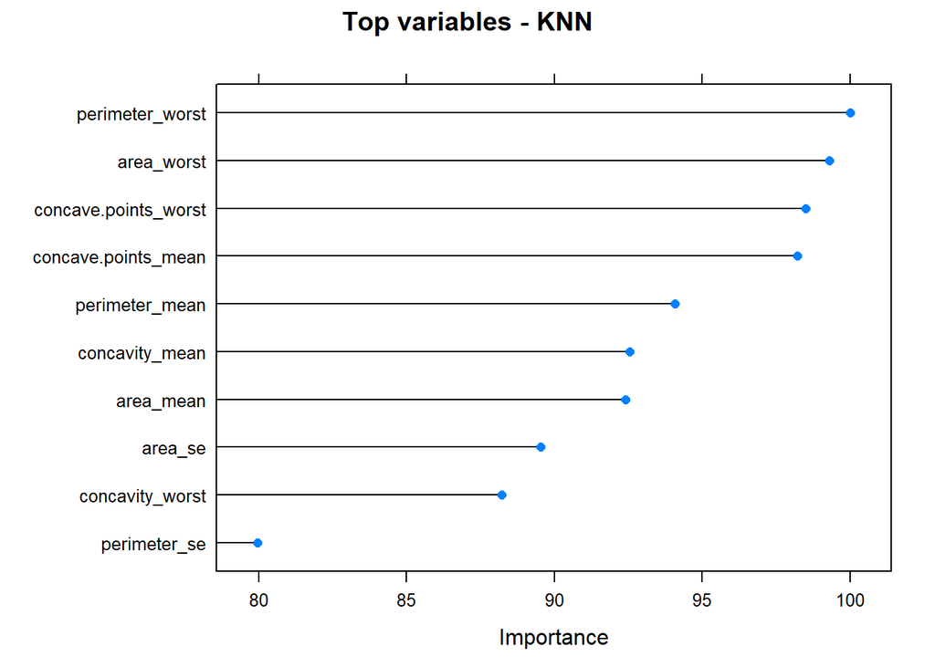

```r
plot(varImp(model_knn), top=10, main="Top variables - KNN")
```

### Neural Network with PCA Model

Artificial Neural Networks (NN) are a types of mathematical algorithms originatingin the simulation of networks of biological neurons. An artificial Neural Network consists of nodes (called neurons) and edges (calledsynapses). Input data is transmitted through the weighted synapses to the neuronswhere calculations are processed and then either sent to further neurons or representthe output.

Neural Networks take in the weights of connections between neurons . The weights are balanced, learning data point in the wake of learning data point . When all weights are trained, the neural network can be utilized to predict the class or a quantity, if there should arise an occurrence of regression of a new input data point. With Neural networks, extremely complex models can be trained and they can be utilized as a kind of black box, without playing out an unpredictable complex feature engineering before training the model. Joined with the “deep approach” even more unpredictable models can be picked up to realize new possibilities.

```r
model_nnet_pca <- train(diagnosis~.,
                        train_data,
                        method="nnet",
                        metric="ROC",
                        preProcess=c('center', 'scale', 'pca'),
                        tuneLength=10,
                        trace=FALSE,
                        trControl=fitControl)

prediction_nnet_pca <- predict(model_nnet_pca, test_data)
confusionmatrix_nnet_pca <- confusionMatrix(prediction_nnet_pca, test_data$diagnosis, positive = "M")
confusionmatrix_nnet_pca
```

```
Confusion Matrix and Statistics

          Reference
Prediction  B  M
         B 70  0
         M  1 42

               Accuracy : 0.9912
                 95% CI : (0.9517, 0.9998)
    No Information Rate : 0.6283
    P-Value [Acc > NIR] : <2e-16

                  Kappa : 0.9811

 Mcnemar's Test P-Value : 1

            Sensitivity : 1.0000
            Specificity : 0.9859
         Pos Pred Value : 0.9767
         Neg Pred Value : 1.0000
             Prevalence : 0.3717
         Detection Rate : 0.3717
   Detection Prevalence : 0.3805
      Balanced Accuracy : 0.9930

       'Positive' Class : M
```

The most important variables that permit the best prediction and contribute the most to the model are the following:

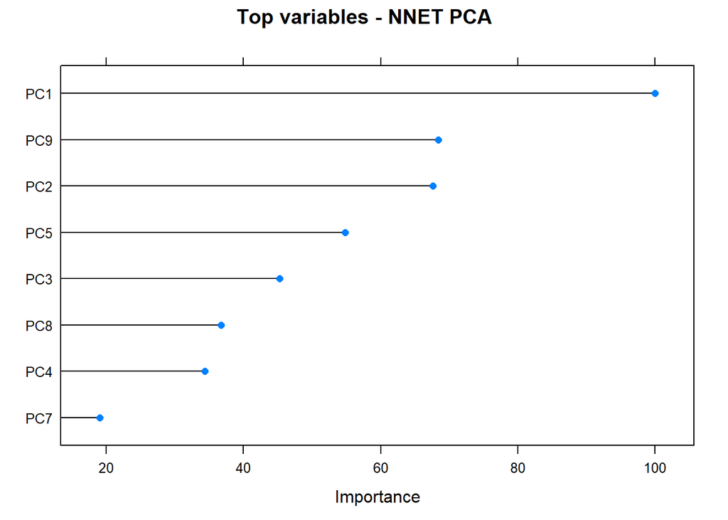

```r
plot(varImp(model_nnet_pca), top=8, main="Top variables - NNET PCA")
```

### Neural Network with LDA Model

We are going to create a training and test set of LDA data created in previous chapters:

```r
train_data_lda <- lda_df_predict[data_sampling_index, ]
test_data_lda <- lda_df_predict[-data_sampling_index, ]
```

```r
model_nnet_lda <- train(diagnosis~.,
                        train_data_lda,
                        method="nnet",
                        metric="ROC",
                        preProcess=c('center', 'scale'),
                        tuneLength=10,
                        trace=FALSE,
                        trControl=fitControl)

prediction_nnet_lda <- predict(model_nnet_lda, test_data_lda)
confusionmatrix_nnet_lda <- confusionMatrix(prediction_nnet_lda, test_data_lda$diagnosis, positive = "M")
confusionmatrix_nnet_lda
```

```
Confusion Matrix and Statistics

          Reference
Prediction  B  M
         B 70  1
         M  1 41

               Accuracy : 0.9823
                 95% CI : (0.9375, 0.9978)
    No Information Rate : 0.6283
    P-Value [Acc > NIR] : <2e-16

                  Kappa : 0.9621

 Mcnemar's Test P-Value : 1

            Sensitivity : 0.9762
            Specificity : 0.9859
         Pos Pred Value : 0.9762
         Neg Pred Value : 0.9859
             Prevalence : 0.3717
         Detection Rate : 0.3628
   Detection Prevalence : 0.3717
      Balanced Accuracy : 0.9811

       'Positive' Class : M
```

# Results

We can now compare and evaluate the results obtained with the above calculations.

```r
models_list <- list(Naive_Bayes=model_naiveb,
                    Logistic_regr=model_logreg,
                    Random_Forest=model_randomforest,
                    KNN=model_knn,
                    Neural_PCA=model_nnet_pca,
                    Neural_LDA=model_nnet_lda)
models_results <- resamples(models_list)

summary(models_results)
```

```
Call:
summary.resamples(object = models_results)

Models: Naive_Bayes, Logistic_regr, Random_Forest, KNN, Neural_PCA, Neural_LDA
Number of resamples: 15

ROC
                   Min.   1st Qu.    Median      Mean  3rd Qu. Max. NA's
Naive_Bayes   0.9473684 0.9760766 0.9904306 0.9832270 0.995614    1    0
Logistic_regr 0.8301435 0.9533493 1.0000000 0.9663477 1.000000    1    0
Random_Forest 0.9473684 0.9856459 0.9978070 0.9902844 1.000000    1    0
KNN           0.9451754 0.9873405 0.9976077 0.9908347 1.000000    1    0
Neural_PCA    0.9605263 0.9932217 1.0000000 0.9937267 1.000000    1    0
Neural_LDA    0.9780702 0.9956140 1.0000000 0.9967092 1.000000    1    0

Sens
                   Min.   1st Qu.    Median      Mean 3rd Qu. Max. NA's
Naive_Bayes   0.8421053 0.9473684 0.9473684 0.9512281       1    1    0
Logistic_regr 0.8421053 0.9236842 1.0000000 0.9582456       1    1    0
Random_Forest 0.8421053 0.9473684 1.0000000 0.9719298       1    1    0
KNN           0.8947368 1.0000000 1.0000000 0.9861404       1    1    0
Neural_PCA    0.9473684 0.9486842 1.0000000 0.9826316       1    1    0
Neural_LDA    0.9473684 1.0000000 1.0000000 0.9894737       1    1    0

Spec
                   Min.   1st Qu.    Median      Mean   3rd Qu. Max. NA's
Naive_Bayes   0.7272727 0.9090909 0.9090909 0.9106061 0.9583333    1    0
Logistic_regr 0.8181818 0.8712121 1.0000000 0.9419192 1.0000000    1    0
Random_Forest 0.8181818 0.8712121 0.9166667 0.9303030 1.0000000    1    0
KNN           0.7272727 0.8712121 0.9166667 0.9136364 1.0000000    1    0
Neural_PCA    0.8181818 0.9090909 0.9166667 0.9414141 1.0000000    1    0
Neural_LDA    0.8181818 0.9128788 1.0000000 0.9585859 1.0000000    1    0
```

As we can observe from the following plot, two models, Naive_bayes and Logistic_regr have great variability, depending of the processed sample :

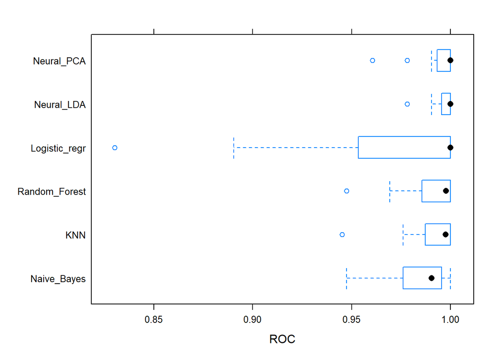

```r
bwplot(models_results, metric="ROC")
```

The Neural Network LDA model achieve a great auc (Area Under the ROC Curve) with some variability. The ROC (Receiver Operating characteristic Curve is a graph showing the performance of a classification model at all classification thresholds) metric measure the auc of the roc curve of each model. This metric is independent of any threshold. Let’s remember how these models result with the testing dataset. Prediction classes are obtained by default with a threshold of 0.5 which could not be the best with an unbalanced dataset like this.

```r
confusionmatrix_list <- list(
  Naive_Bayes=confusionmatrix_naiveb,
  Logistic_regr=confusionmatrix_logreg,
  Random_Forest=confusionmatrix_randomforest,
  KNN=confusionmatrix_knn,
  Neural_PCA=confusionmatrix_nnet_pca,
  Neural_LDA=confusionmatrix_nnet_lda)
confusionmatrix_list_results <- sapply(confusionmatrix_list, function(x) x$byClass)
confusionmatrix_list_results %>% knitr::kable()
```

|  | Naive_Bayes | Logistic_regr | Random_Forest | KNN | Neural_PCA | Neural_LDA |
| --- | --- | --- | --- | --- | --- | --- |
| Sensitivity | 0.9285714 | 1.0000000 | 0.9761905 | 0.9285714 | 1.0000000 | 0.9761905 |
| Specificity | 0.9295775 | 0.9436620 | 0.9859155 | 1.0000000 | 0.9859155 | 0.9859155 |
| Pos Pred Value | 0.8863636 | 0.9130435 | 0.9761905 | 1.0000000 | 0.9767442 | 0.9761905 |
| Neg Pred Value | 0.9565217 | 1.0000000 | 0.9859155 | 0.9594595 | 1.0000000 | 0.9859155 |
| Precision | 0.8863636 | 0.9130435 | 0.9761905 | 1.0000000 | 0.9767442 | 0.9761905 |
| Recall | 0.9285714 | 1.0000000 | 0.9761905 | 0.9285714 | 1.0000000 | 0.9761905 |
| F1 | 0.9069767 | 0.9545455 | 0.9761905 | 0.9629630 | 0.9882353 | 0.9761905 |
| Prevalence | 0.3716814 | 0.3716814 | 0.3716814 | 0.3716814 | 0.3716814 | 0.3716814 |
| Detection Rate | 0.3451327 | 0.3716814 | 0.3628319 | 0.3451327 | 0.3716814 | 0.3628319 |
| Detection Prevalence | 0.3893805 | 0.4070796 | 0.3716814 | 0.3451327 | 0.3805310 | 0.3716814 |
| Balanced Accuracy | 0.9290744 | 0.9718310 | 0.9810530 | 0.9642857 | 0.9929577 | 0.9810530 |

# Discussion

We will now describe the metrics that we will compare in this section.

Accuracy is our starting point. It is the number of correct predictions made divided by the total number of predictions made, multiplied by 100 to turn it into a percentage.

Precision is the number of True Positives divided by the number of True Positives and False Positives. Put another way, it is the number of positive predictions divided by the total number of positive class values predicted. It is also called the Positive Predictive Value (PPV). A low precision can also indicate a large number of False Positives.

Recall (Sensitivity) is the number of True Positives divided by the number of True Positives and the number of False Negatives. Put another way it is the number of positive predictions divided by the number of positive class values in the test data. It is also called Sensitivity or the True Positive Rate. Recall can be thought of as a measure of a classifiers completeness. A low recall indicates many False Negatives.

The F1 Score is the 2 x ((precision x recall) / (precision + recall)). It is also called the F Score or the F Measure. Put another way, the F1 score conveys the balance between the precision and the recall.

```r
confusionmatrix_results_max <- apply(confusionmatrix_list_results, 1, which.is.max)

output_report <- data.frame(metric=names(confusionmatrix_results_max),
                            best_model=colnames(confusionmatrix_list_results)[confusionmatrix_results_max],
                            value=mapply(function(x,y) {confusionmatrix_list_results[x,y]},
                                         names(confusionmatrix_results_max),
                                         confusionmatrix_results_max))
rownames(output_report) <- NULL
output_report
```

```
                 metric    best_model     value
1           Sensitivity    Neural_PCA 1.0000000
2           Specificity           KNN 1.0000000
3        Pos Pred Value           KNN 1.0000000
4        Neg Pred Value Logistic_regr 1.0000000
5             Precision           KNN 1.0000000
6                Recall Logistic_regr 1.0000000
7                    F1    Neural_PCA 0.9882353
8            Prevalence Random_Forest 0.3716814
9        Detection Rate Logistic_regr 0.3716814
10 Detection Prevalence Logistic_regr 0.4070796
11    Balanced Accuracy    Neural_PCA 0.9929577
```

# Conclusion

This paper treats the Wisconsin Madison Breast Cancer diagnosis problem as a pattern classification problem. In this report we investigated several machine learning model and we selected the optimal model by selecting a high accuracy level combinated with a low rate of false-negatives (the means that the metric is high sensitivity).